# Homework 5

林恒旭 21210980049@m.fudan.edu.cn

2022/4/20

## 1. 读入catalogs.xlsx，并使用head()函数查看数据形式。

```r
library(readxl)
catalog <- read_excel("catalogs.xlsx")
# 查看数据
head(catalog)
```

```
## # A tibble: 6 x 4
##   name                                                        first second  third
##   <chr>                                                       <chr> <chr>   <chr>
## 1 双汇 猪舌 700g/袋                                           生鲜  猪牛羊~ 猪肉
## 2 （满38减10）黑猪腊肉 湘西腊肉 即食小吃食猪肉干肉脯湖南张家~ 生鲜  猪牛羊~ 猪肉
## 3 精气神 猪肋排段（排骨） 400g/袋 山黑猪  黑猪肉 林间散养     生鲜  猪牛羊~ 猪肉
## 4 双汇 猪五花肉片 300g/袋 整肉原切 火锅食材                   生鲜  猪牛羊~ 猪肉
## 5 农家散养新鲜现杀黑土猪肉 纯瘦肉  500g                       生鲜  猪牛羊~ 猪肉
## 6 精气神 猪腿肉 400g/袋 山黑猪 黑猪肉 林间散养（2件起售）     生鲜  猪牛羊~ 猪肉
```

## 2. 使用ggplot函数，分别绘制“生鲜”和“食品饮料、保健食品”两个一级品类下二级品类分布的饼图，并进行解读。

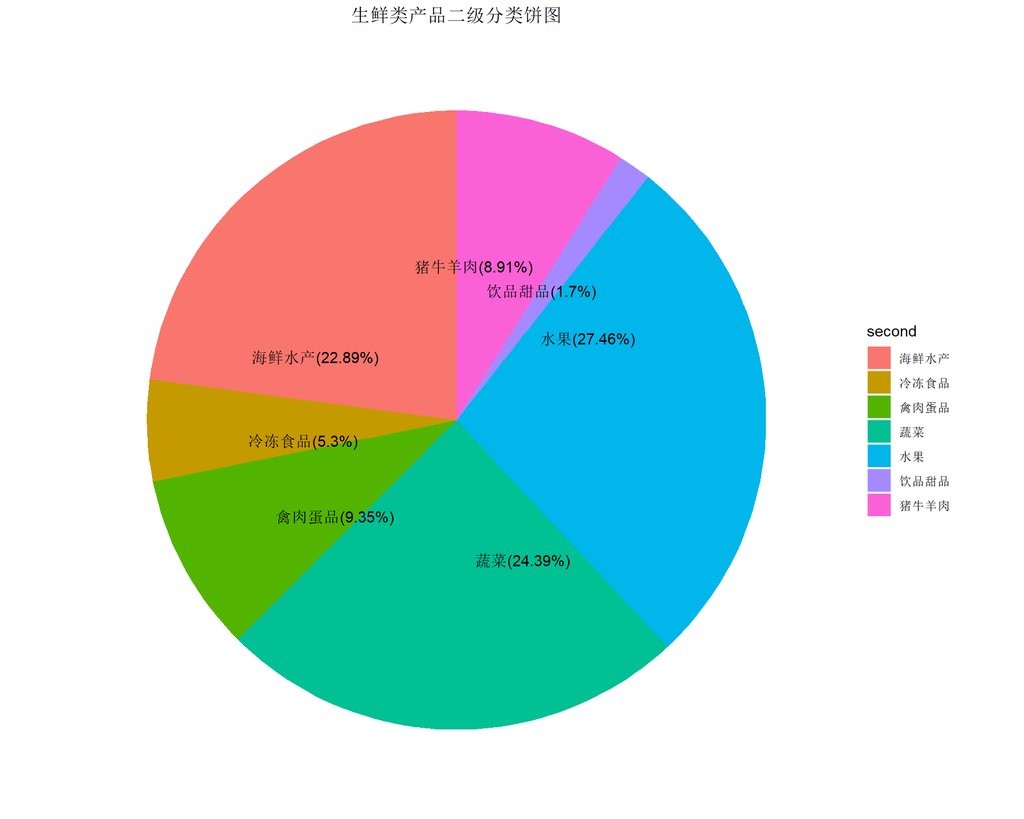

```r
library(plyr)
library(ggplot2)
# 聚合数据
df1 <- ddply(catalog[catalog$first=="生鲜",], .(second), nrow)
# help(ddply)
df1 <- df1[order(df1$V1, decreasing = TRUE),]
# 获取标签
label <- as.vector(df1$second)
label <- paste(label, "(", round(df1$V1/sum(df1$V1)*100, 2), "%)", sep = "")

ggplot(df1, aes(x="", y=V1, fill=second)) +
geom_bar(width = 1, stat = "identity") +
  coord_polar("y", start=0) +
  geom_text(aes(label=label), position=position_stack(vjust=0.2)) +
  labs(title = "生鲜类产品二级分类饼图") +
  theme(axis.text = element_blank(),
        axis.ticks = element_blank(),
        axis.title = element_blank(),
        panel.background =element_rect(fill='white'),
        plot.title = element_text(hjust=0.5))
```

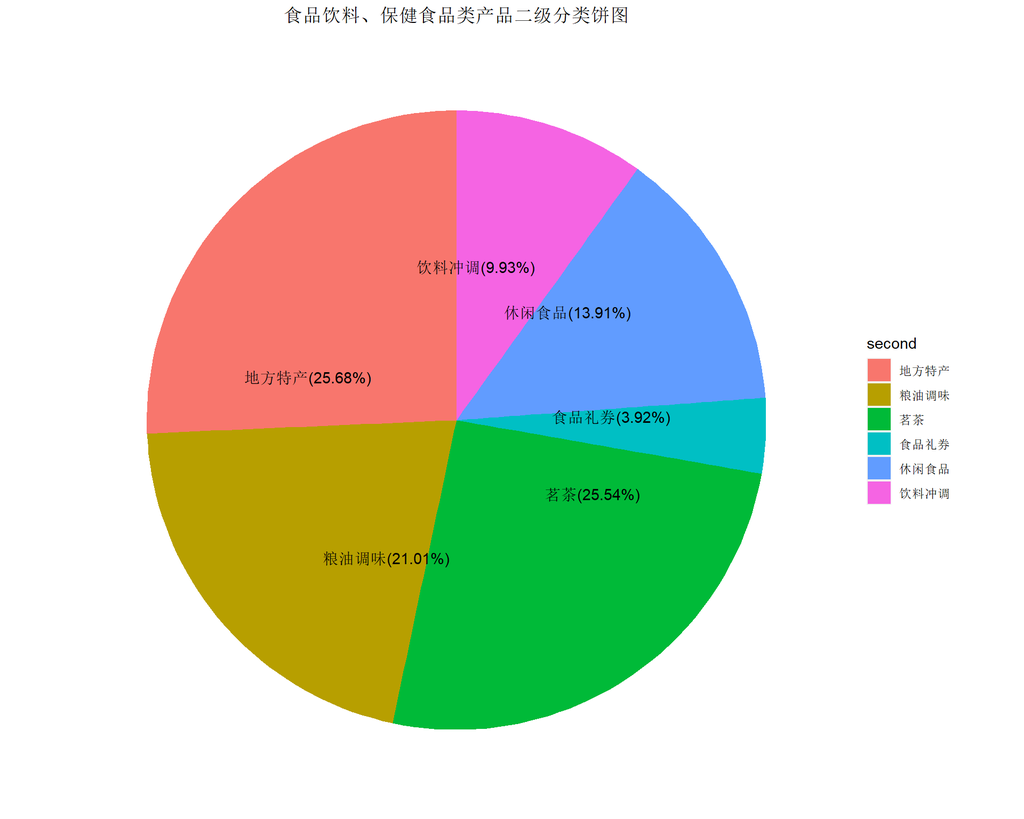

```r
# 聚合数据
df2 <- ddply(catalog[catalog$first=="食品饮料、保健食品",], .(second), nrow)
df2 <- df2[order(df2$V1, decreasing = TRUE),]
# 获取标签
label <- as.vector(df2$second)
label <- paste(label, "(", round(df2$V1/sum(df2$V1)*100, 2), "%)", sep = "")

ggplot(df2, aes(x="", y=V1, fill=second)) +
geom_bar(width = 1, stat = "identity") +
  coord_polar("y", start=0) +
  geom_text(aes(label=label), position=position_stack(vjust=0.2)) +
  labs(title = "食品饮料、保健食品类产品二级分类饼图") +
  theme(axis.text = element_blank(),
        axis.ticks = element_blank(),
        axis.title = element_blank(),
        panel.background =element_rect(fill='white'),
        plot.title = element_text(hjust=0.5))
```

生鲜类产品一共有七种，七种水果、蔬菜、海鲜水产占据了大部分。食品饮料、保健食品类产品一共有6种，其中茗茶、地方特产、粮油调味占据了大部分。

## 3. 进行商品名称的处理

使用jiebaR包中的分词函数对商品名称进行分词处理。为了更精确的分词结果，我们提供了一个自定义词典，即“userdict.dat”，请再自定义撰写一个包含5个停用词的“stop_words.dat”，加载到分词worker中，对全部商品名称进行分词。

```r
library(jiebaR)
# 自定义撰写停用词
stop_words <- data.frame(V1=c("的", "是", "和", "个", "不"))
write.table(stop_words, file="stop_words.dat")
```

```r
# 加载到worker中对全部商品进行分词
seg = worker(byline=T)
new_words <- read.table('userdict.dat', header = F, stringsAsFactors = F, encoding="UTF-8")
stop_words <- read.table('stop_words.dat', stringsAsFactors = F)
new_user_word(seg, new_words$V1)
```

```
## [1] TRUE
```

```r
new_user_word(seg, stop_words$V1)
```

```
## [1] TRUE
```

```r
# 分词
catalog$name = as.character(catalog$name)
cata_seg = segment(catalog$name, seg)
```

## 4. 单词数量的直方图

基于上一题的分词结果，使用apply族的函数分别计算 “生鲜”和“食品饮料、保健食品”两个类别下，每个商品名称分词后单词的数量，并以此使用ggplot函数绘制两个一级品类商品名称分词后单词数量的直方图。 ### 4.1 生鲜类的分词结果

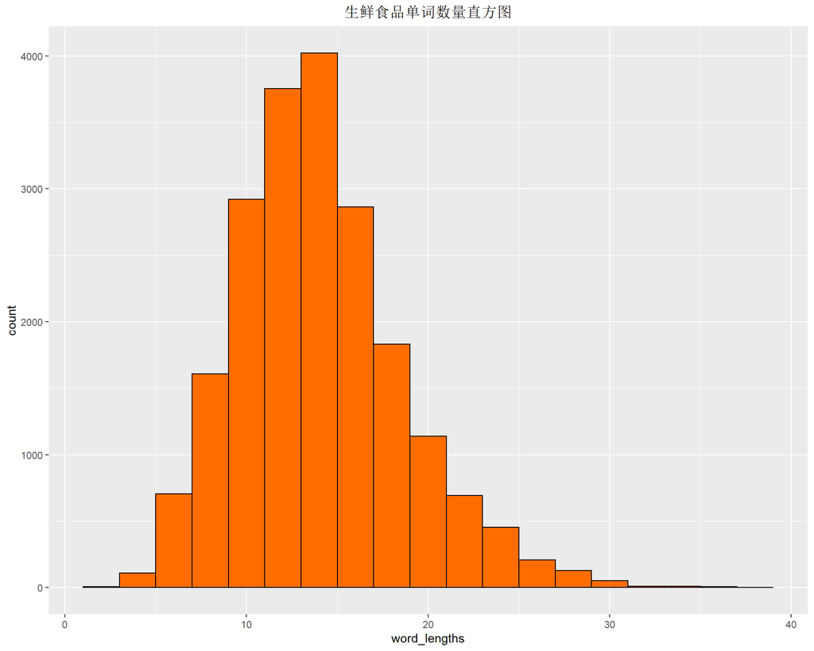

```r
fresh_seg = cata_seg[which(catalog$first == '生鲜')]
word_lengths <- sapply(fresh_seg, length)
word_lengths <- as.data.frame(word_lengths)
ggplot(word_lengths, aes(word_lengths)) +
  geom_histogram(bins=20, fill="#FF6D00FF", color="black") +
  ggtitle("生鲜食品单词数量直方图") +
  theme(plot.title = element_text(hjust = 0.5))
```

### 4.2 “食品饮料、保健食品”的分词结果

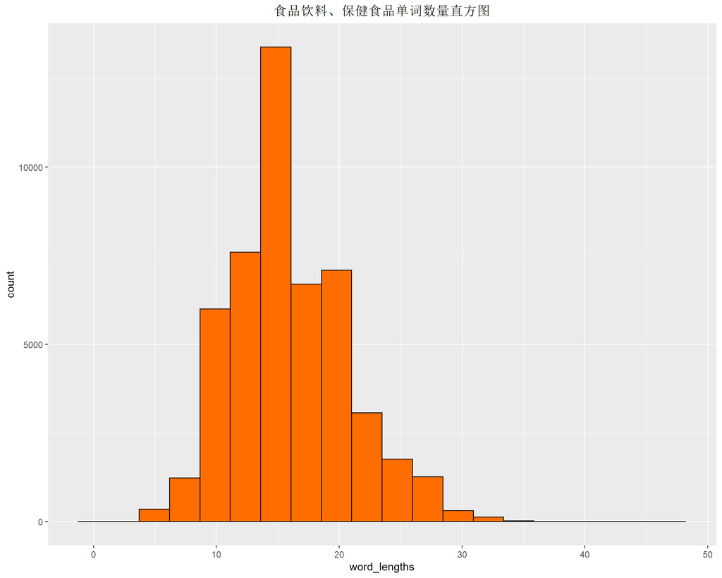

```r
food_and_drink_seg = cata_seg[which(catalog$first == '食品饮料、保健食品')]
word_lengths <- sapply(food_and_drink_seg, length)
word_lengths <- as.data.frame(word_lengths)
ggplot(word_lengths, aes(word_lengths)) +
  geom_histogram(bins=20, fill="#FF6D00FF", color="black") +
  ggtitle("食品饮料、保健食品单词数量直方图") +
  theme(plot.title = element_text(hjust = 0.5))
```

## 5. 词云图

分别绘制“食品饮料、保健食品”类别下三级品类“牛奶乳品”和“成人奶粉”商品名称分词后的top100高频词的词云图，比较两种品类商品名称的语言特点，并做简单点评。

### 5.1 建立分词后词频数据框

```r
library(wordcloud2)
milk_seg <-  cata_seg[which(catalog$third == '牛奶乳品')]
milk_seg_df <- data.frame(table(unlist(milk_seg)))
milk_seg_df <- milk_seg_df[order(milk_seg_df$Freq,decreasing=T),]
powder_seg <-  cata_seg[which(catalog$third == '成人奶粉')]
powder_seg_df <- data.frame(table(unlist(powder_seg)))
powder_seg_df <- powder_seg_df[order(powder_seg_df$Freq,decreasing=T),]
```

### 5.2 对前100个词构建词云图

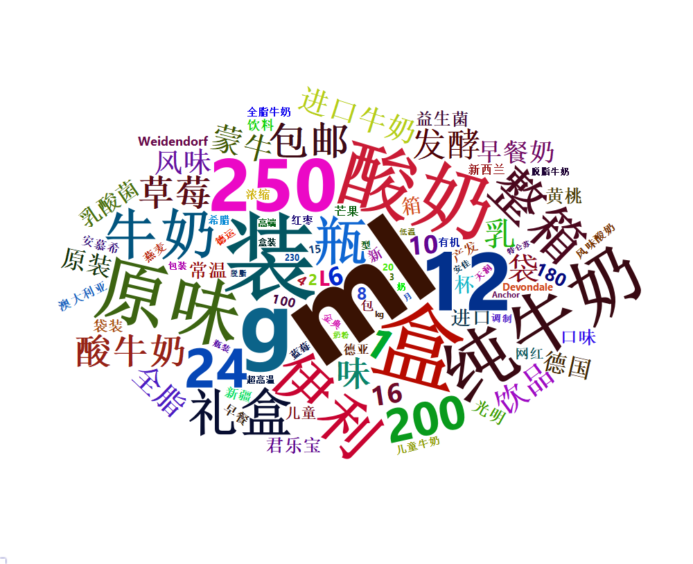

```r
library(wordcloud2)
library(webshot)
library(htmlwidgets)
my_graph <- wordcloud2(milk_seg_df[1:100,])
saveWidget(my_graph, "tmp.html", selfcontained = F)
webshot("tmp.html", "wc1.png", delay = 5, vwidth = 1000, vheight = 800)
```

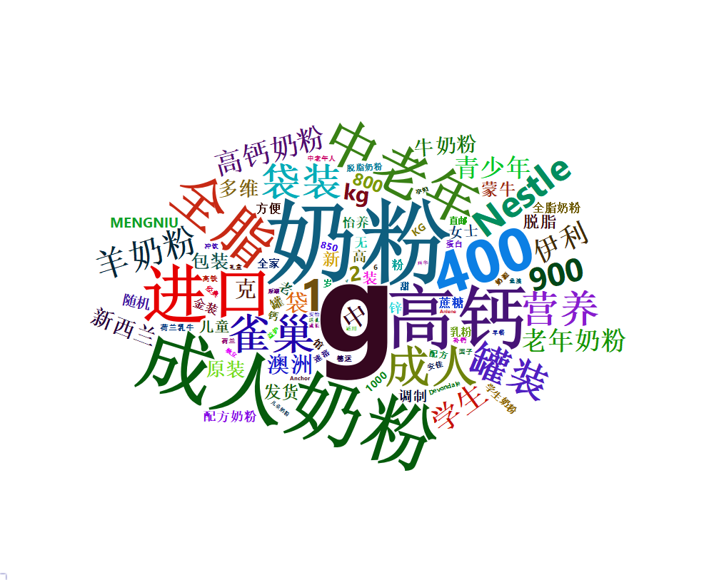

```r
my_graph <- wordcloud2(powder_seg_df[1:100,])
saveWidget(my_graph, "tmp.html", selfcontained = F)
webshot("tmp.html", "wc2.png", delay = 5, vwidth = 1000, vheight = 800)
```

可以看到，牛奶乳品的商品名称多是对奶的分类，例如纯牛奶、酸奶、风味酸奶、脱脂牛奶等，并且也有大量的量词，例如盒、箱、瓶子。而成人奶粉多是适用人群，例如学生、中老年、成人，并且有对营养成分的表述，例如高钙、锌等。

## 6. 建立文档-词频矩阵

对分词结果进行预处理，预处理包括去掉纯数字或者纯字母的组合，去掉低频词（包含该词的商品数量<10）、高频词（在多于75%的商品名称中出现），在去除低频词和高频词时，可以使用函数pruned_vocab()。最后，保留高频词中的top1000的词语，作为分类器的特征，并建立文档-词频矩阵。在建立文档词频矩阵时，需要用到text2vec包中的create_dtm()函数

### 6.1 去掉纯数字或者纯字母的组合

```r
library(text2vec)
it_cata_seg <- itoken(cata_seg)
vocab <- create_vocabulary(it_cata_seg)
stop_words <- unique(unlist(cata_seg))
stop_words <- stop_words[grepl('^([a-z]|[A-Z])+$',stop_words)|grepl('^[0-9]+(\\.)?[0-9]*(-)?[0-9]*(\\.)?[0-9]*$',stop_words)]
stop_words <- setdiff(stop_words, new_words)
pruned_vocab <- vocab[!(vocab$term %in% stop_words),]
```

### 6.2 去掉低频词（包含该词的商品数量<10）、高频词（在多于75%的商品名称中出现）

```r
pruned_vocab <- prune_vocabulary(pruned_vocab, doc_count_min=10, doc_proportion_max=0.75)
```

### 6.3 保留高频词中的top1000的词语，作为分类器的特征，并建立文档-词频矩阵

```r
pruned_vocab <- pruned_vocab[order(pruned_vocab$term_count, decreasing=T),]
pruned_vocab <- pruned_vocab[1:1000,]
vectorizer <- vocab_vectorizer(pruned_vocab)
dtm_all <- create_dtm(it_cata_seg, vectorizer)
dtm_all <- as.matrix(dtm_all)
dtm_all[dtm_all>1] <- 1
dtm_all <- apply(dtm_all, 2, as.factor)
```

## 7. 构建朴素贝叶斯分类器

挑选出“食品饮料、保健食品”类的样本，构建朴素贝叶斯分类器。固定随机数种子为666，按照7:3将这部分样本划分为训练集与测试集两部分。使用e1071包中的naiveBayes()函数构建朴素贝叶斯分类器，并计算测试集上的预测准确率。

### 7.1 划分为训练集与测试集

```r
library(e1071)
set.seed(666)
food_and_drink <- catalog[catalog$first == '食品饮料、保健食品',]
id <- sample(1:nrow(food_and_drink), 0.7*nrow(food_and_drink), F)
train <- food_and_drink[id,]
test <- food_and_drink[-id,]
dtm_food_and_drink <- dtm_all[catalog$first=='食品饮料、保健食品',]
dtm_train <- dtm_food_and_drink[id,]
dtm_test <- dtm_food_and_drink[-id,]
```

### 7.2 构建朴素贝叶斯分类器

```r
nb <- naiveBayes(x=dtm_train, y=as.factor(train$second),laplace=0)
```

### 7.3 计算测试集上的预测准确率

```r
pred <- predict(nb, dtm_test, type='class')
accuracy <- sum(as.character(test$second) == as.character(pred)) / nrow(test)
print(paste0('食品饮料、保健食品：', accuracy))
```

```
## [1] "食品饮料、保健食品：0.84616431829011"
```

## 8.混淆矩阵

```r
### 输出混淆矩阵
real <- as.character(test$second)
tab <- table(pred, as.character(test$second))
tab[tab==0] <- NA
print(list(ConfusionMatrix = tab))
```

```
## $ConfusionMatrix
##
## pred       地方特产 粮油调味 茗茶 食品礼券 休闲食品 饮料冲调
##   地方特产     2705      319   52       14      251       17
##   粮油调味      510     2614   64        2       41       29
##   茗茶           84       32 3501        6        6       10
##   食品礼券       59       22    3      522        8        1
##   休闲食品      400       53   20       13     1705        6
##   饮料冲调       60       72   56        8       42     1384
```

从混淆矩阵可以看到，茗茶、饮料冲调的预测准确率较高，这是因为这些商品的名称有着明显的语言特征，例如这些商品往往包含饮料、茶等词。而地方特产、粮油调味、休闲食品的预测准确率较低，地方特产、粮油调味、休闲食品三者易混淆，这是因为三者有着共同的语言特征，例如某些调味品，或者某些休闲食品，就是地方特产。